# Sentiment

Winston Saunders

May 9, 2016

### SUMMARY

This continuation of [BIAS AND CONTEXT IN PRESIDENTIAL DEBATE TEXTS](https://rpubs.com/ww44ss/Debate_Text) and HEAT MAPS & LINGUISTICS OF DEBATE SPEECH in R, which focused on a “Bag of Words” approach to analyzing the text of Presidential Debates for the 2016 Election Cycle.

## DATA SOURCES AND METHODS

The text of the presidential debates are downloaded from the [UCSB Presidency Project](http://www.presidency.ucsb.edu/debates.php). Transcripts were pasted into Apple Pages and stored as unformatted .txt files.

## DEMOCRAITC DEBATES

Here are the dates of the analyzed Democratic Debates

```r
print(xtable(as.matrix(unique(d_all_f$debate)), align = c("c", "c")), type="html", include.rownames=FALSE, include.colnames = FALSE)
```

| October 13 2015 |
| --- |
| November 14 2015 |
| December 19 2015 |
| January 17 2016 |
| February 4 2016 |
| February 11 2016 |
| March 6 2016 |
| March 9 2016 |
| April 14 2016 |

### Republican Debates

Here are the dates of the analyzed Republican Debates

```r
print(xtable(as.matrix(unique(r_all_f$debate)), align = c("c", "c")), type="html", include.rownames=FALSE, include.colnames = FALSE)
```

| October 28 2015 |
| --- |
| March 10 2016 |
| November 10 2015 |
| December 15 2015 |
| January 14 2016 |
| January 28 2016 |
| February 6 2016 |
| February 13 2016 |
| February 25 2016 |
| March 3 2016 |

## Use `mutate()` to add computed sentiment

We’ll use the `mutate()` to add a “sentiment” column to the data. In this case I’ll just use two of the standard methods “bing” and “afinn” included in the package. Each of these associates a specific “sentiment” to a set of words, then simply sums the result.

```r
## add sentiment using two different methods (afinn and bing)
d_all_f <- mutate(d_all_f, afinn_sentiment = get_sentiment(d_all_f$text, method = "afinn"), bing_sentiment = get_sentiment(d_all_f$text, method = "bing"))

r_all_f <- mutate(r_all_f, afinn_sentiment = get_sentiment(r_all_f$text, method = "afinn"), bing_sentiment = get_sentiment(r_all_f$text, method = "bing"))
```

### Democratic Debate Sentiment

The plot below shows the trend of the overall sentiment of the all debates and all candidates. The “other” category lumps all audience and moderator comments together.

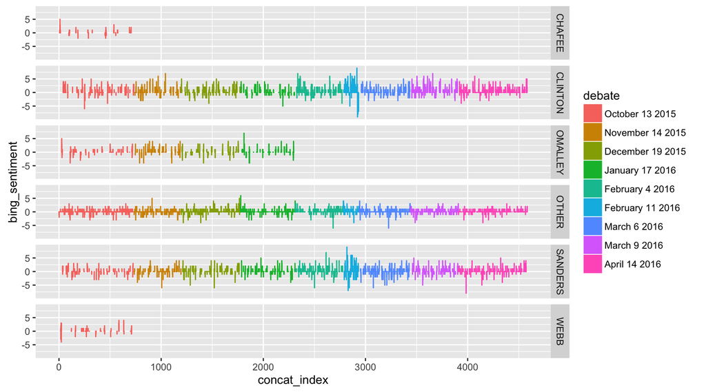

Notice that the candidate sentiments have high variablity than do the moderators (as might be expected), with the debate of February 11 2016 standing out. [Press Coverage](http://www.cnn.com/2016/02/11/politics/democratic-debate-highlights/) of the February 11, 2016 debate revealed the following comments:  
*Much of the debate lacked the bitterness…[but] the confrontation during the PBS “NewsHour” Democratic debate simulcast on CNN flared into open anger in the final moments.* *Clinton accused her rival of not standing with Obama after he endorsed a book by CNN contributor Bill Press critical of the president. She said Sanders had called Obama “weak” and a “disappointment” in the past and she warned “the kind of criticism that we heard from Sen. Sanders about our president, I expect from Republicans. I do not expect (it) from someone running for the Democratic nomination to succeed President Obama.”*

Let’s see if we can pick this up….

### Use `filter()` to drill into February 11 2016

Again we can use `{dplyr}` functions to get the data and then use the transform function in the `{syuzhet}` package to extract low frequency components.

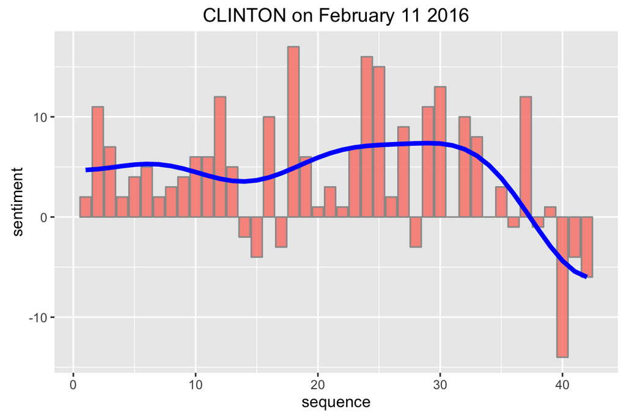

| seq | text | afinn | bing |
| --- | --- | --- | --- |
| 39 | I certainly agree with FDR for all the reasons Senator Sanders said And I agree about the role that he played both in war and in peace on the economy and defeating fascism around the world I would cho… | 1 | 3 |
| 40 | But I want to — I want to follow up on something having to do with leadership, because, you know, today Senator Sanders said that President Obama failed the presidential leadership test And this is no… | -14 | -9 |
| 41 | You know, Senator, what I am concerned about, is not disagreement on issues, saying that this is what I would rather do, I dont agree with the president on that, calling the president weak, calling hi… | -4 | -8 |

```r
candidate_x <- "CLINTON"
debate_x <- "February 11 2016"
single_d_debate <- d_all_f %>% filter(debate == debate_x, name == candidate_x)
filtered.sentiment = get_dct_transform(single_d_debate$afinn_sentiment, x_reverse_len=nrow(single_d_debate), low_pass_size = 7)

tt <- filtered.sentiment %>% as.data.frame()
ttx <- cbind(tt, single_d_debate$afinn_sentiment)
colnames(ttx) <- c("filtered", "sentiment")

p <- ggplot(ttx, aes(y = filtered, x=seq_along(filtered))) +
    geom_bar(aes(y=sentiment), stat='identity', fill="salmon", color = "grey60", alpha=0.8) +
    geom_line(color = "blue", size = 1.5) +
    ggtitle(paste(candidate_x, "on", debate_x))+
    xlab("sequence") +
    ylab("sentiment")

p
```

## Republican Debate Sentiment

There were are a lot more candidates in the Republican filed, so the density of data is lower, especially in the earlier debates, where there was a plethora of them.

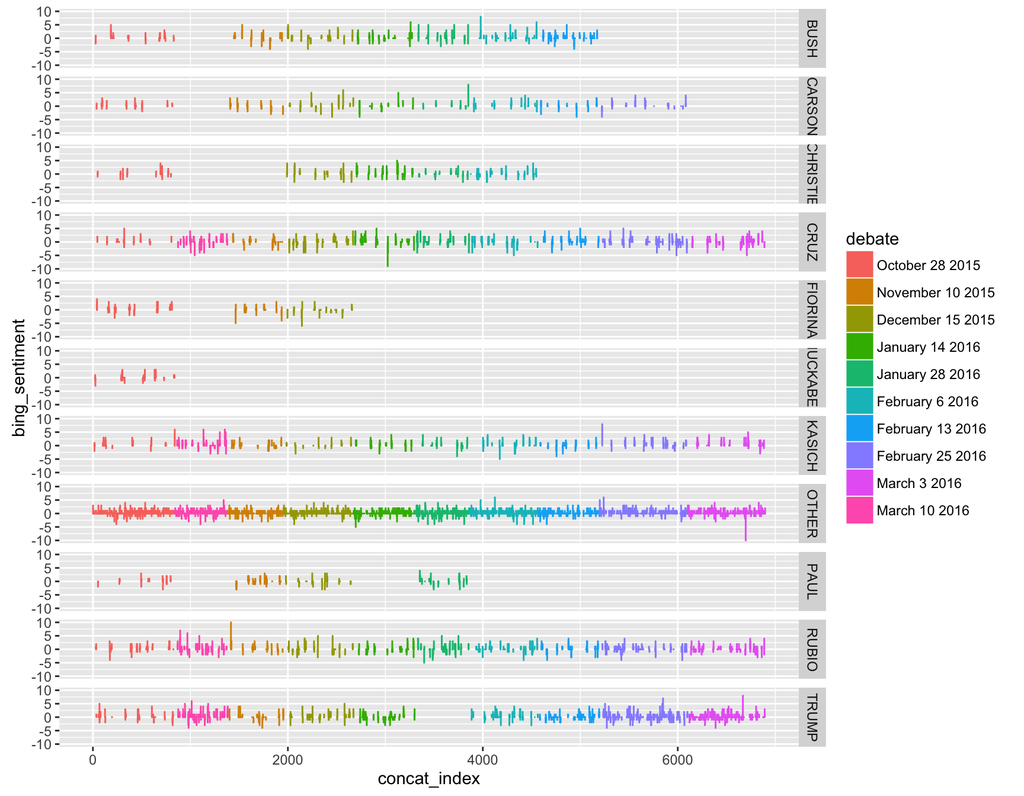

### Donald Trump’s Penis March 3, 2016

The March 3, 2016 Republican debate will forever live in infamy because it struck possibly the lowest note of a presidential debate, ever. The press headlines read [Donald Trump defends size of his penis](http://www.cnn.com/2016/03/03/politics/donald-trump-small-hands-marco-rubio/) in coverage of a remarkable exchange with Marco Rubio.

Again we can use `filter()` to get the data and then use the transform function in the `{syuzhet}` package to extract low frequency components.

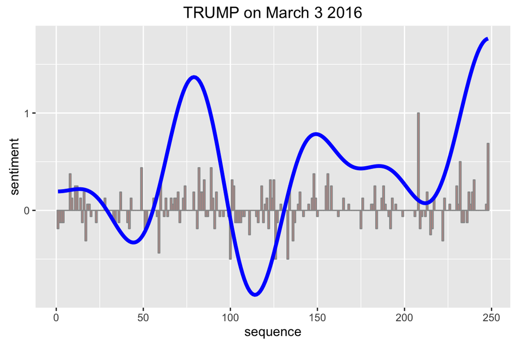

| seq | text | afinn | bing |
| --- | --- | --- | --- |
| 14 | Well, I also happened to call him a lightweight, OK? And I have said that So I would like to take that back He is really not that much of a lightweight And as far as — and I have to say this, I have t… | 2 | 2 |
| 15 | And he referred to my hands, if they are small, something else must be small I guarantee you there is no problem I guarantee | -2 | 0 |
| 16 | I have heard Ted say that over and over again on television, that he is the only one that can beat me Just, for the record, I have won 10 He has won three or four Last week, in fact, on Tuesday, I was… | 3 | 1 |

```r
candidate_x <- "TRUMP"
debate_x <- "March 3 2016"
single_r_debate <- r_all_f %>% filter(debate == debate_x, name == candidate_x)
filtered.sentiment = get_dct_transform(single_r_debate$afinn_sentiment, x_reverse_len=nrow(single_r_debate), low_pass_size = 10)

tt <- filtered.sentiment %>% as.data.frame()
ttx <- cbind(tt, single_r_debate$afinn_sentiment)
colnames(ttx) <- c("filtered", "sentiment")

p <- ggplot(ttx, aes(y = filtered, x=seq_along(filtered))) +
    geom_bar(aes(y=sentiment/max(sentiment)), stat='identity', fill="salmon", color = "grey60", alpha=0.8) +
    geom_line(color = "blue", size = 1.5) +
    ggtitle(paste(candidate_x, "on", debate_x))+
    xlab("sequence") +
    ylab("sentiment")

p
```

### Using `filter()` to plot a histogram of specific candidate sentiment

#### SANDERS

```r
sanders_sent <- d_all_f %>% filter(name == "SANDERS")
```

overall the distribution is pretty uninteresting

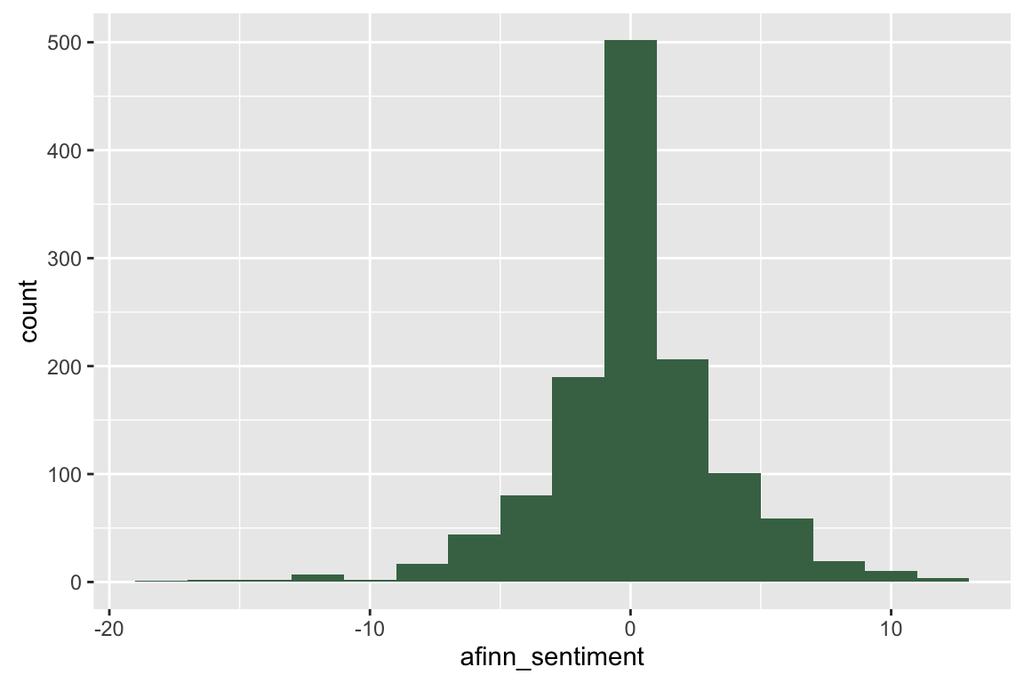

```r
ggplot(sanders_sent, (aes(x = afinn_sentiment))) + geom_histogram(binwidth=2,fill="#467254")
```

however, if we look at the densities of individual debates we can see some subtle differences.

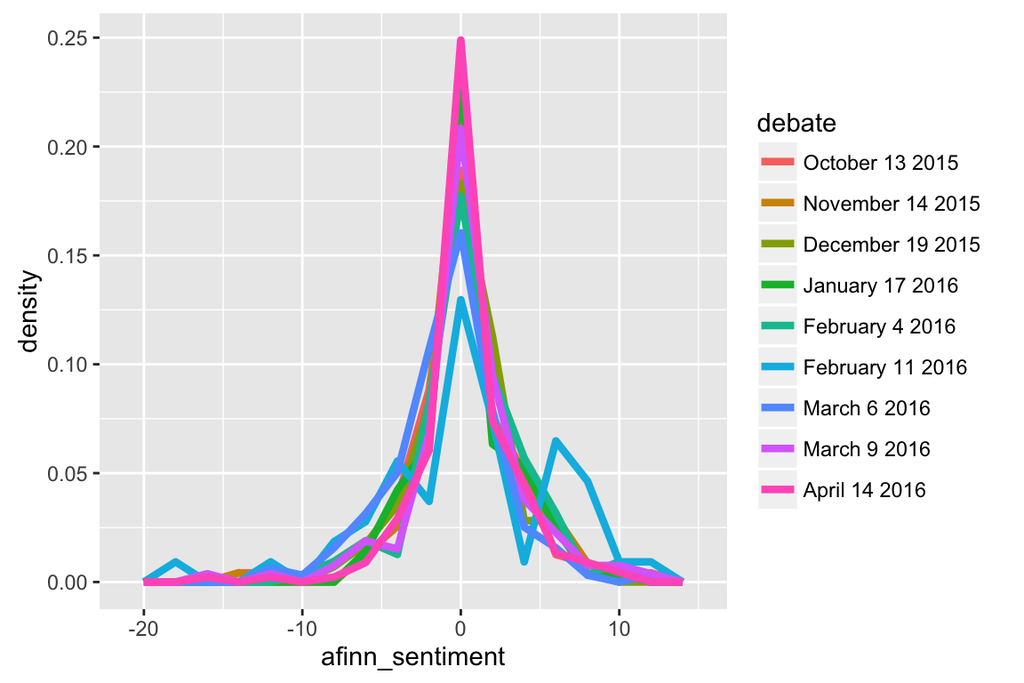

```r
ggplot(sanders_sent, aes(x=afinn_sentiment, ..density.., color = debate)) +
  geom_freqpoly(binwidth = 2, size=1.5)
```

```r
sanders_high <- filter(d_all_f, name== "SANDERS", debate == "February 11 2016", afinn_sentiment >= 5, afinn_sentiment <= 7)
sanders_high$text[c(1, 3)]
```

```
## [1] "Look, we are fighting for every vote that we can get from women, from men, straight, gay, African-Americans, Latinos, Asian-Americans We are trying to bring America together around an agenda that works for working families and the middle class I am very proud, if my memory is not correct — I…
## [2] "Let me, you know, again, respectfully disagree with Secretary Clinton here When you have three out of the four largest financial institutions in this country bigger today than they were when we bailed them out because they were too big to fail, when you have six financial institutions having…
```

#### CRUZ

```r
can_sent <- r_all_f %>% filter(name == "CRUZ")
```

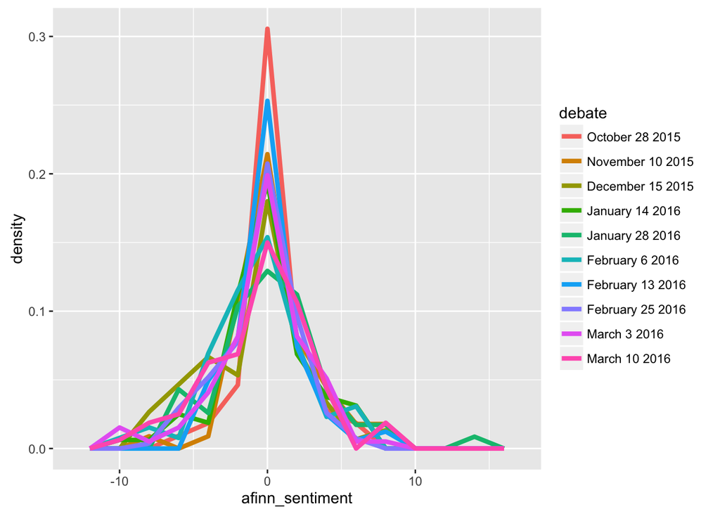

```r
ggplot(can_sent, aes(x=afinn_sentiment, ..density.., color = debate)) +
  geom_freqpoly(binwidth = 2, size=1.5)
```

```r
cruz_low <- filter(r_all_f, name== "CRUZ", debate == "December 15 2015", afinn_sentiment >= -6, afinn_sentiment <= -4)

cruz_low$text[5:6]
```

```
## [1] "What it means is using overwhelming air power to utterly and completely destroy Isis To put things in perspective, in the first Persian Gulf War, we launched roughly 1,100 air attacks a day We carpet bombed them for 36 days, saturation bombing, after which our troops went in and in a day and…
## [2] "Right now, Obama is launching between 15 and 30 air attacks a day It is photo op foreign policy We need to use overwhelming air power We need to be arming the Kurds We need to be fighting and killing Isis where they are"
```

### Use **group_by()** to look at summary debate stats

#### Democrats

We can look at the mean sentiment expressed in each debate by the two leading Democratic candidates.

```r
dem_stat <- group_by(d_all_f, name, debate)
summarize(dem_stat, mean_afinn = mean(afinn_sentiment), mean_bing = mean(bing_sentiment)) %>% filter(name == "CLINTON")
```

```
## Source: local data frame [9 x 4]
## Groups: name [1]
##
##      name           debate mean_afinn mean_bing
##     (chr)           (fctr)      (dbl)     (dbl)
## 1 CLINTON  October 13 2015   1.373239 0.7253521
## 2 CLINTON November 14 2015   1.448598 0.6728972
## 3 CLINTON December 19 2015   1.278146 0.6688742
## 4 CLINTON  January 17 2016   1.028571 0.5142857
## 5 CLINTON  February 4 2016   1.746753 0.7532468
## 6 CLINTON February 11 2016   4.190476 2.0476190
## 7 CLINTON     March 6 2016   1.312500 0.7222222
## 8 CLINTON     March 9 2016   2.241135 1.1063830
## 9 CLINTON    April 14 2016   1.329004 0.7099567
```

```r
summarize(dem_stat, mean_afinn = mean(afinn_sentiment), mean_bing = mean(bing_sentiment)) %>% filter(name == "SANDERS")
```

```
## Source: local data frame [9 x 4]
## Groups: name [1]
##
##      name           debate mean_afinn mean_bing
##     (chr)           (fctr)      (dbl)     (dbl)
## 1 SANDERS  October 13 2015  0.2521008 0.1764706
## 2 SANDERS November 14 2015  0.8290598 0.1794872
## 3 SANDERS December 19 2015  0.4507042 0.2394366
## 4 SANDERS  January 17 2016  0.7676056 0.2816901
## 5 SANDERS  February 4 2016  0.9936709 0.4936709
## 6 SANDERS February 11 2016  0.8703704 0.5925926
## 7 SANDERS     March 6 2016 -0.4528302 0.0754717
## 8 SANDERS     March 9 2016  0.7651515 0.3636364
## 9 SANDERS    April 14 2016  0.6367713 0.3004484
```

Here is a plot of the data

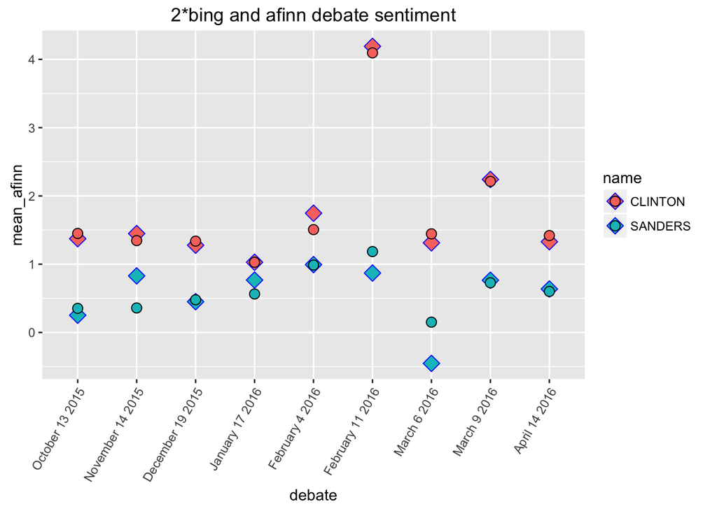

```r
clinton <- summarize(dem_stat, mean_afinn = mean(afinn_sentiment), mean_bing = mean(bing_sentiment)) %>% filter(name == "CLINTON")

sanders <- summarize(dem_stat, mean_afinn = mean(afinn_sentiment), mean_bing = mean(bing_sentiment)) %>% filter(name == "SANDERS")

ggplot(rbind(clinton, sanders), aes(x = debate, y = mean_afinn, fill = name)) + geom_point(pch = 23, size = 4, color = "blue") + geom_point(size = 3, pch = 21, aes(y= 2*mean_bing))+theme(axis.text.x = element_text(angle=60, hjust=1)) + ggtitle("2*bing and afinn debate sentiment")
```

These correlate prety well.

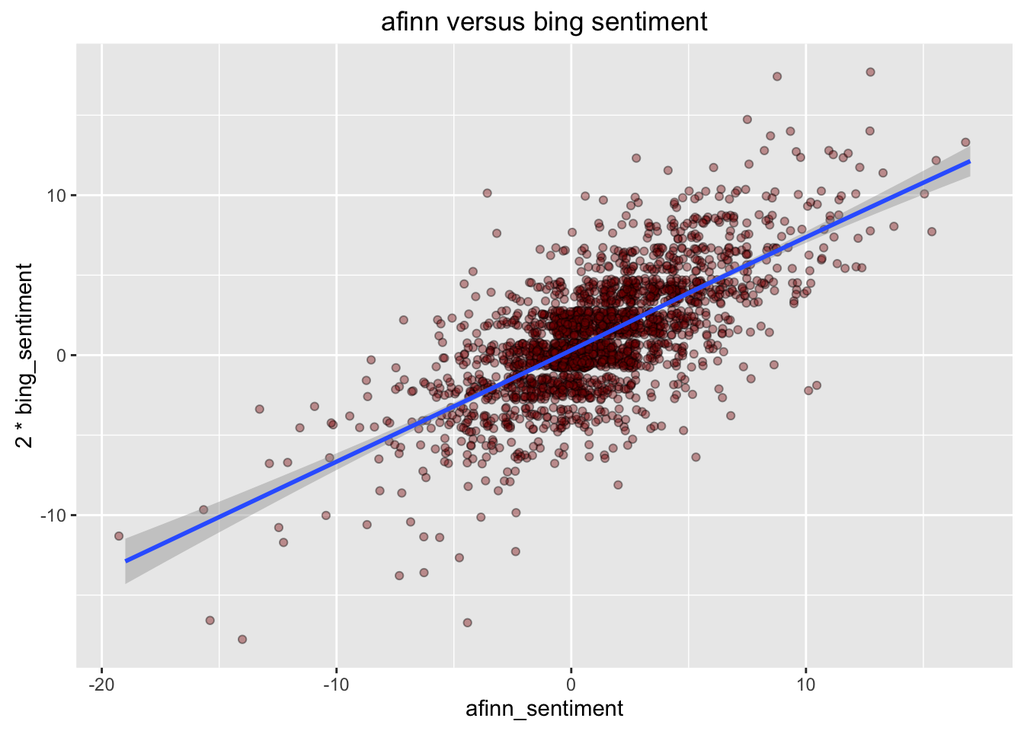

```r
ggplot(d_all_f %>% filter(name == "SANDERS" | name == "CLINTON"), aes(x = afinn_sentiment, y = 2*bing_sentiment)) + geom_jitter(pch=21, width=2, height=2, alpha=.4, fill = "darkred") + geom_smooth(formula = y ~ x) + ggtitle("afinn versus bing sentiment")
```

```r
#+ geom_point(alpha = 0.3, size = 3)
```

#### Republican

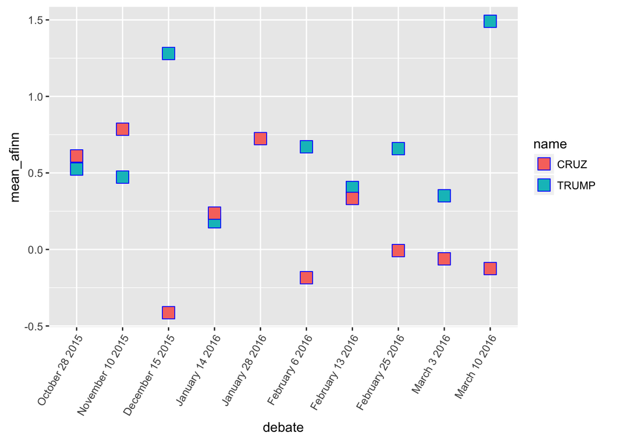

### Polarized Statements

What statements were the most polarized (i.e. most positive and negative) of each candidate. We can slice this using filter and summarize.

#### Hillary Clinton

##### Max Positive Sentiment (afinn)

```r
hillary_max <- d_all_f %>% filter(name == "CLINTON") %>% filter(afinn_sentiment == max(afinn_sentiment))
```

```
## [1] "I strongly support the presidents executive actions I hope the Supreme Court upholds them I think there is constitutional and legal authority for the president to have done what he did I am against the raids Im against the kind of inhumane treatment that is now being visited upon families, w…
```

```r
hillary_max <- d_all_f %>% filter(name == "CLINTON") %>% filter(afinn_sentiment == max(bing_sentiment))
```

```
##  [1] "You know, I have to say, I was very pleased when Governor OMalley endorsed me for president in 2008, and I enjoyed his strong support in that campaign And I consider him, obviously, a friend"
##  [2] "And I have to tell you, I would not want -- if I lived in Iowa, Terry Branstad administering my health care I -- I think -- I think as Democrats we ought to proudly support the Affordable Care Act, improve it, and make it the model that we know it can be"
##  [3] "But I also want to create jobs and I want to be a partner with the private sector Im particularly keen on creating jobs in small business My dad was a small businessman, a really small business I want to do more to help incentivize and create more small businesses So if -- if people who are…
##  [4] "But, with all due respect, to start over again with a whole new debate is something that I think would set us back The Republicans just voted last week to repeal the Affordable Care Act, and thank goodness, President Obama vetoed it and saved Obamacare for the American people "
##  [5] "Look, I have the greatest respect for Senator Sanders and for his supports and Im going to keep working as hard as I can to reach as many people of all ages about what I will do, what the experience and the ideas that I have that I will bring to the White House and I hope to have their supp…
##  [6] "I also believe in affordable college, but I dont believe in free college, because every expert that I have talked to says, look, how will you ever control the costs What I want to do is make sure middle class kids, not Donald Trumps kids, get to be able to afford college I want to get the e…
##  [7] "And Im very proud and grateful to have the support of so many elected Vermonters and former officials Two former governors, the current governor, the current other senator I really appreciate that"
##  [8] "Absolutely And, you know, there are a number of programs that I think are duplicative and redundant and not producing the results that people deserve There are a lot of training programs and education programs that I think can be streamlined and put into a much better format so that if we d…
##  [9] "Your government at all levels have let you and your children and the people of Flint down So I think that there are there several things All the repair work that is being done — and Mayor Weaver program that we support to begin to help train people in Flint to be able to do this work to dis…
## [10] "We need to do more to help create clean energy as a source of good jobs but I am also going to go after companies You know, when a company decides to leave like Nabisco is leaving and they have gotten tax benefits from Chicago and Illinois to stay there, I will claw back the benefits They w…
## [11] "Well, Im running for president to do my very best to knock down every barrier that stands in the way of America realizing its potential and every American having a chance to live up to his or her God-given potential We have a lot of work to do We have economic barriers Thats why Ive laid ou…
## [12] "But we also need to be having a positive agenda for manufacturing for small businesses and entrepreneurs, for more clean energy jobs And I also look forward to discussing comprehensive immigration reform with a path to citizenship that will be one of my priorities in my first 100 days as pr…
## [13] "I think our best chance was in 2007, when Ted Kennedy led the charge on comprehensive immigration reform We have Republican support We had a president willing to sign it I voted for that bill Senator Sanders voted against it"
## [14] "They deserve to be treated as citizens and to be given the opportunity to get back on their feet economically And I just want to add one thing to the question you were asking Senator Sanders I think in that same interview, he praised what he called the revolution of values in Cuba and talke…
## [15] "And, you know, I am getting a little bit — Im getting a little bit concerned here because, you know, I really believe that the President has done an incredible job against great odds and deserves to be supported [cheering and applause]"
```

##### Max Negative Sentiment (afinn)

```
## [1] "But I want to — I want to follow up on something having to do with leadership, because, you know, today Senator Sanders said that President Obama failed the presidential leadership test And this is not the first time that he has criticized President Obama In the past he has called him weak H…
```

#### Donald Trump

##### Max Positive Sentiment (afinn)

```r
donald_max <- r_all_f %>% filter(name == "TRUMP") %>% filter(afinn_sentiment == max(afinn_sentiment))
```

```
## [1] "The Republican Party has a great chance to embrace millions of people that its never known before Theyre coming by the millions We should seize that opportunity These are great people These are fantastic people These are people that love our country These are people that want to see America …
## [2] "Well, I can only say — look, I can only say Ive been a big contributor to Israel over the years Ive received many, many awards from Israel, as Ive said before I have a great relationship with Israel And Im going to keep it that way And if I could bring peace, that would be a fantastic thing …
## [3] "Then he goes, we have five And — well, excuse me, I won 10 I won 10 states If you listen to him, its like — I won 10 states Everybody knows that on Super Tuesday Trump was the winner There wasnt one person that didnt say that Even the two people on your left and right said we did a great job…
```

```r
donald_max <- r_all_f %>% filter(name == "TRUMP") %>% filter(afinn_sentiment == max(bing_sentiment))
```

```
## [1] "And the reason is they have a fantastic lobby They take care of all of the senators, the Congressmen They have great power and they dont bid out The military is never properly bid When we go out to military bids, its not properly bid And the people that really sell us the product are oftenti…
## [2] "But were all having a good time and the next day, on the Today Show and a couple of other place, not too many Because when you look at it, everyones smiling, laughing Their arms are raised like this They had pictures, still pictures of people and they tried to equate it to Nazi Germany"
## [3] "We will fight We will win And we truly will make this even more special We have to make it better than ever before And I will tell you, the United States can actually be better than ever before Thank you"
## [4] "Well, I think I am, and to me, I view the word conservative as a derivative I — of — of the word conserve We want to converse our money We want to conserve our wealth We want to conserve We want to be smart We want to be smart where we go, where we spend, how we spend We want to conserve our…
## [5] "Oh, let me just say — look, I am very open — I hired top people Ive had great success I built a great, great company I dont need to do this Im self-funding Im spending a lot of money Ive spent — like in New Hampshire, I spent $3 million Jeb bush spent $44 million He came in five, and I came …
## [6] "But, we either have a country, or we dont have a country We have at least 11 million people in this country that came in illegally They will go out They will come back — some will come back, the best, through a process They have to come back legally They have to come back through a process, …
## [7] "Its wonderful to stand up for two days and do that Now, Teds been very critical — I have a sister whos a brilliant"
## [8] "I will prove to be a great leader And, you know, its very interesting, we talk about the polls Every single poll when it comes to Isis and the military and the border say, by far, Trump is the best"
```

##### Max Negative Sentiment (afinn)

```
##  [1] "But I will be putting — I will be putting up, you know, tremendous amounts of money SuperPacs are a disaster Theyre a scam They cause dishonesty And you better get rid of them because they are causing a lot of bad decisions to be made by some very good people And Im not blaming these folks …
##  [2] "By the way, unlike our country where were totally predictable and the enemy, whether its Isis or anybody else, they know exactly what were doing because we have the wrong leadership "
##  [3] "But I feel that the gun-free zones and, you know, when you say that, thats target practice for the sickos and for the mentally ill Thats target They look around for gun-free zones You know, we could give you another example — the Marines, the Army, these wonderful six soldiers that were kil…
##  [4] "As far as the families are concerned, and as far as the law is concerned, we have a law — this all started with your question on water boarding We have a law that doesnt allow right now water boarding They have no laws They have no rules They have no regulations They chop off heads They dro…
##  [5] "And its not me Its usually the municipal government, the police because I dont have guards all over these stadiums I mean, we fill up stadiums Its usually the police — and, by the way, speaking of the police, we should pay our respects to the police because they are taking tremendous abuse …
##  [6] "But, if Putin wants to go and knocked the hell out of Isis, I am all for it, 100%, and I cant understand how anybody would be against it"
##  [7] "Assad is a bad guy, but we have no idea who the so-called rebels — I read about the rebels, nobody even knows who they are I spoke to a general two weeks ago, he said — he was very up on exactly what were talking about He said, You know, Mr Trump? Were giving hundreds of millions of dollars…
##  [8] "Okay First of all, Nikki this afternoon said Im a friend of hers Actually a close friend And wherever you are sitting Nikki, Im a friend Were friends Thats good But she did say there was anger And I could say, oh, Im not angry Im very angry because our country is being run horribly and I wi…
##  [9] "No I am a 2nd amendment person If we had guns in California on the other side where the bullets went in the different direction, you wouldnt have 14 or 15 people dead right now"
## [10] "If even in Paris, if they had guns on the other side, going in the opposite direction, you wouldnt have 130 people plus dead So the answer is no and what Jeb said is absolutely correct"
## [11] "I want security Im tired of seeing whats going on, between the border where the people flow over; people come in; they live; they shoot I want security for this country We have a serious problem with, as you know, with radical Islam We have a tremendous problem Its not only a problem here I…
## [12] "I think he has no idea what hes doing And our country is going to hell So, I just want to say, we disagree on that Is that okay?"
## [13] "We actually have a case where we dont want to bomb the oil, because we dont want to hurt — pollute the atmosphere Can you imagine General Douglas MacArthur or General Patton saying we cant bomb because were gonna hurt the atmosphere?"
## [14] "He went back, it was a mistake, it wasnt a mistake It took him five days before his people told him what to say, and he ultimately said, It was a mistake The war in Iraq, we spent $2 trillion, thousands of lives, we dont even have it Iran has taken over Iraq, with the second-largest oil res…
## [15] "George Bush made a mistake We can make mistakes But that one was a beauty We should have never been in Iraq We have destabilized the Middle East"
## [16] "This is not what we need in our country We need people that know what the hell theyre doing And politicians, theyre all talk, theyre no action And thats why people are supporting me"
## [17] "It is very unfair, that criticism Now, I will say this, with all of that being said, I have said I will not do it at all, because if I say a word thats a little bit off color, a little bit, it ends up being a headline"
## [18] "That is a rough thing And I know Ted feels badly about it And I think he probably still respects the judge But that judge has been a disaster in terms of everything we stand for because there is no way — no way that he should have approved Obamacare"
## [19] "When you say crazy zealot, are you talking about you? Crazy zealot — give me a break"
## [20] "The biggest problem, Ill have you know"
## [21] "But a poll just came out — a Bloomberg poll — where I am beating him so badly that its, like, embarrassing even for me to say Im beating him that badly "
## [22] "first of all, hes talking about the polls Im beating him awfully badly in the polls"
## [23] "No, no Youre the liar Youre the lying guy up here"
## [24] "No, Im a big defender of the Second Amendment And if you look at whats happened, whether its in California, where you had the 14 people killed, whether its in Paris — which, by the way, has the toughest gun laws in the world and 130 people killed Many, many people in the hospital gravely in…
```

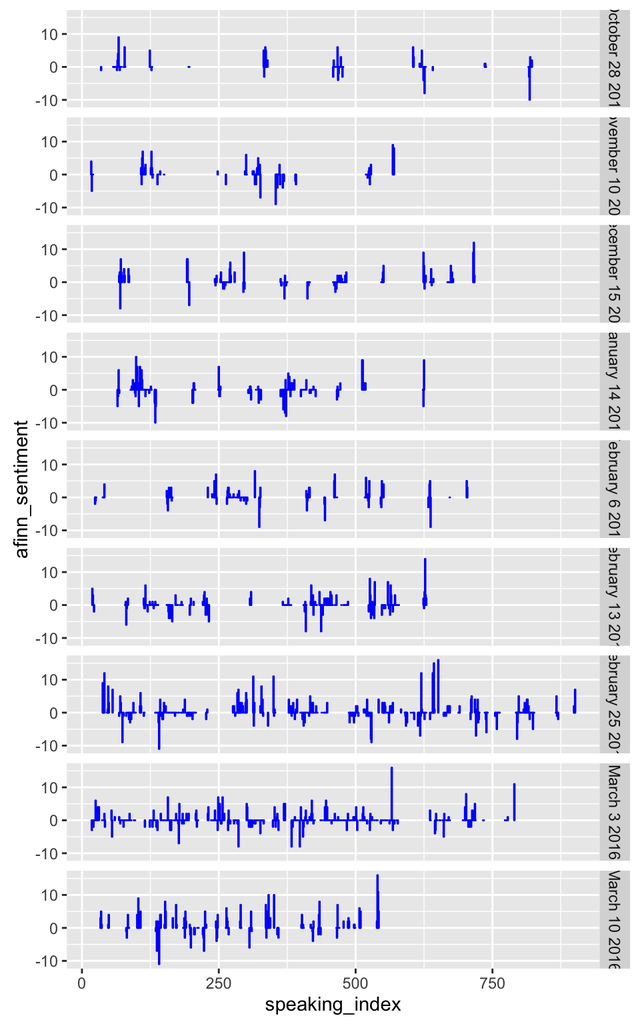

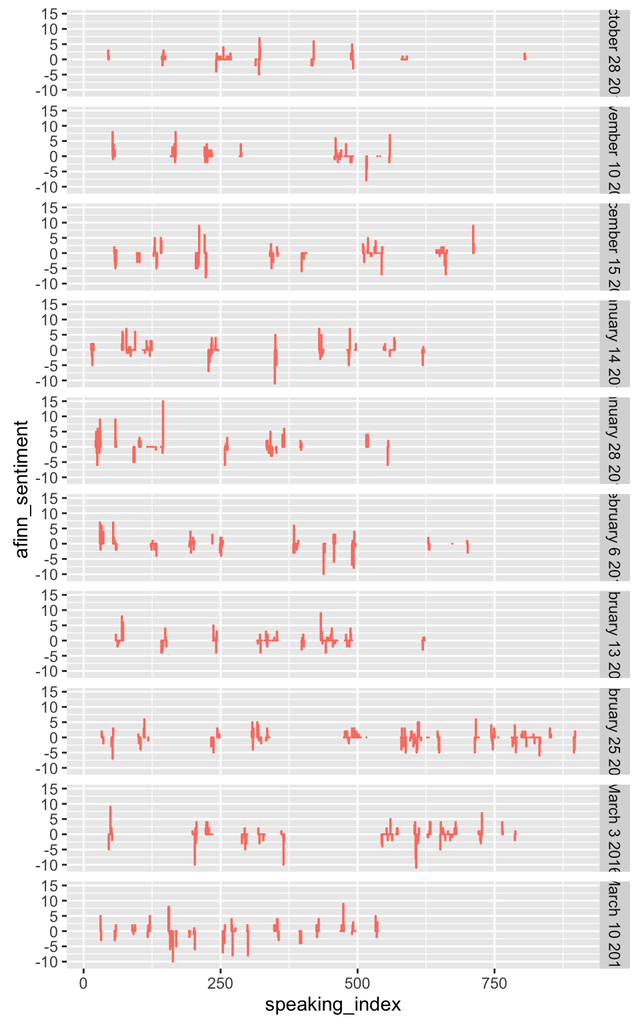